# Postulación Spike

Bryan Casanova

01/Agosto/2021

## Carga de librerias y datos

```r
library(tidyverse)
library(lubridate)
library(firatheme)
library(corrplot)
library(caret)
library(Boruta)
library(randomForest)

precip <- read.csv("https://raw.githubusercontent.com/SpikeLab-CL/desafio_spike_precios/main/precipitaciones.csv") %>% as_tibble()
banco <- read.csv("https://raw.githubusercontent.com/SpikeLab-CL/desafio_spike_precios/main/banco_central.csv") %>%
  as_tibble()
leche <- read.csv("https://raw.githubusercontent.com/SpikeLab-CL/desafio_spike_precios/main/precio_leche.csv") %>% as_tibble()
```

## Análisis de datos

### Precipitación

Primero voy a visualizar las bases de datos para ver qué información tienen y en qué formato. Empezaré por los datos de precipitación

```r
precip
```

```
## # A tibble: 496 x 9
##    date  Coquimbo Valparaiso Metropolitana_d… Libertador_Gral…   Maule  Biobio
##    <fct>    <dbl>      <dbl>            <dbl>            <dbl>   <dbl>   <dbl>
##  1 1989…  0.719     0.117             0.0283             0     7.25e-1 9.17e+0
##  2 1998…  0.0652    0                 0.0115             0     8.97e-3 2.09e+0
##  3 2001…  2.03      0.0480            0.00263            0     3.22e-2 1.08e+1
##  4 2008…  0.623     0                 0.0159             0     1.73e+0 2.51e+1
##  5 2009…  0.00807   0                 0.00940            0     1.21e+1 5.62e+1
##  6 2015…  0.239     0.0256            0.365              0     1.19e-2 1.17e-3
##  7 2016…  1.41      0.174             0.0569             0     4.65e-1 1.52e+1
##  8 2020…  0.00345   0.000666          0                  0     1.16e-1 1.25e+1
##  9 1988…  3.61      7.69              5.76               1.35  5.67e+0 2.99e+1
## 10 2015…  0.273     0.283             0.689              0.410 5.13e-1 2.01e+1
## # … with 486 more rows, and 2 more variables: La_Araucania <dbl>,
## #   Los_Rios <dbl>
```

Vemos que tiene una columna con la fecha, y los datos de precipitación para 8 regiones. Dado que la columna date se leyó como factor, la transformaré a formato fecha. Además voy a ordenar los datos por fecha desde los más antiguos a los más nuevos y eliminaré posibles filas repetidas. Finalmente, para facilitar la visualización y el código, acortaré el nombre de algunas columnas

```r
precip <- precip %>%
  mutate(date = ymd(date)) %>%
  arrange(date) %>%
  distinct() %>%
  rename(Metropolitana = Metropolitana_de_Santiago,
         OHiggins= Libertador_Gral__Bernardo_O_Higgins)
```

Ahora realizaré un pequeño análisis exploratorio: Comenzaré contanto la cantidad de datos no nulos que se dispone por region

```r
precip %>%
    gather(key = region, value = value, -date) %>%
    group_by(region) %>%
    filter(!is.na(value)) %>%
    count()
```

```
## # A tibble: 8 x 2
## # Groups:   region [8]
##   region            n
##   <chr>         <int>
## 1 Biobio          496
## 2 Coquimbo        496
## 3 La_Araucania    496
## 4 Los_Rios        496
## 5 Maule           496
## 6 Metropolitana   496
## 7 OHiggins        496
## 8 Valparaiso      496
```

Entonces, se cuenta con 496 datos de precipitaciones mensuales para las 8 regiones.

Ahora veré el rango de fechas con el que se cuenta datos.

```r
precip %>%
  pull(date) %>%
  range()
```

```
## [1] "1979-01-01" "2020-04-01"
```

Por lo tanto se tienen datos de precipitación desde el año 1979 a abril 2020, lo que corresponde a los 496 datos de precipitación mensual para cada región

Ahora visualizaré la distribución de las precipitaciones por región por medio de un histograma. Nótese que las escalas de ambos ejes son independientes para cada región.

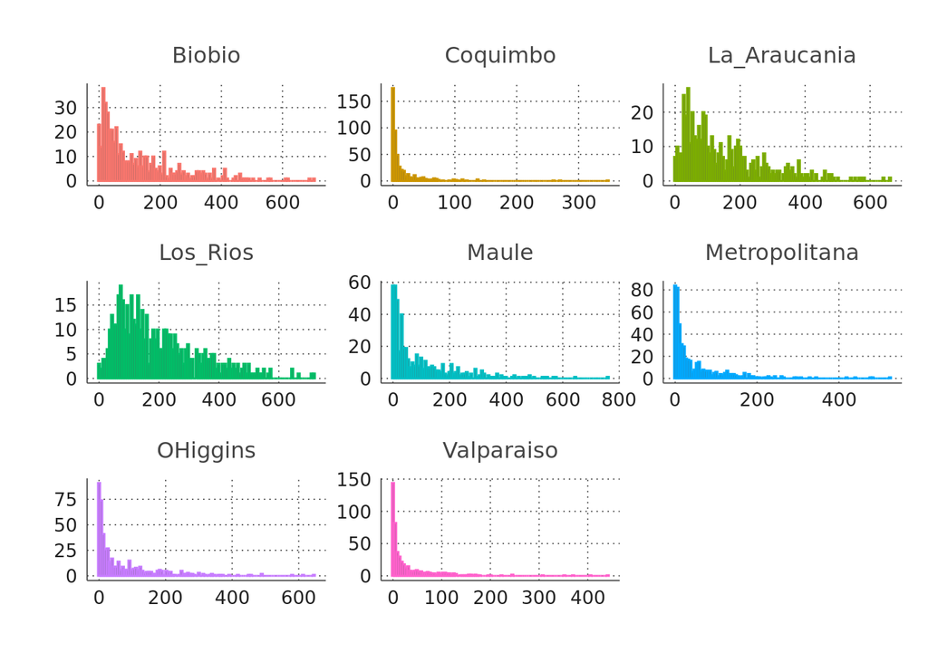

```r
precip %>%
  gather(key = region, value = value, -date) %>%
  ggplot(aes(x = value, color = region)) +
    geom_histogram(bins = 100) +
    theme_fira() +
    facet_wrap(region ~., scales = "free") +
    labs(x = "", y = "") +
    theme(legend.position = "none")
```

Se observa que la mayoría de las distribuciones son log normal, la cual es común de encontrar al analizar variables naturales o ambientales, y que existen mayores precipitaciones en las regiones del sur del país en comparación a las de la zona norte.

### Banco central

Replicaré los pasos anteriores con los datos del banco central, comenzando entonces por visualizar los datos.

```r
banco
```

```
## # A tibble: 614 x 85
##    Periodo Imacec_empalmado Imacec_producci… Imacec_minero Imacec_industria
##    <fct>   <fct>            <fct>            <fct>         <fct>
##  1 2013-0… 102.796.218      10.546.824       978.554.365   102.297.537
##  2 2013-0… 101.664.842      999.272.757      927.333.293   104.485.589
##  3 2013-0… 101.642.954      993.959.922      96.133.164    105.445.361
##  4 2013-0… 998.310.201      968.367.884      102.400.933   999.212.106
##  5 2013-0… 964.696.194      961.051.418      980.029.022   100.882.112
##  6 2013-0… 993.089.872      959.559.679      102.692.682   99.581.119
##  7 2013-0… 950.851.786      913.878.449      103.290.693   903.876.015
##  8 2013-1… 102.727.926      101.742.025      106.829.225   102.778.378
##  9 2013-1… 105.750.158      103.950.101      108.805.134   100.421.866
## 10 2013-1… 108.648.049      111.725.441      110.363.063   102.233.834
## # … with 604 more rows, and 80 more variables: Imacec_resto_de_bienes <fct>,
## #   Imacec_comercio <fct>, Imacec_servicios <fct>,
## #   Imacec_a_costo_de_factores <fct>, Imacec_no_minero <fct>,
## #   PIB_Agropecuario_silvicola <fct>, PIB_Pesca <fct>, PIB_Mineria <fct>,
## #   PIB_Mineria_del_cobre <fct>, PIB_Otras_actividades_mineras <fct>,
## #   PIB_Industria_Manufacturera <fct>, PIB_Alimentos <fct>,
## #   PIB_Bebidas_y_tabaco <fct>, PIB_Textil <fct>, PIB_Maderas_y_muebles <fct>,
## #   PIB_Celulosa <fct>, PIB_Refinacion_de_petroleo <fct>, PIB_Quimica <fct>,
## #   PIB_Minerales_no_metalicos_y_metalica_basica <fct>,
## #   PIB_Productos_metalicos <fct>, PIB_Electricidad <fct>,
## #   PIB_Construccion <fct>, PIB_Comercio <fct>,
## #   PIB_Restaurantes_y_hoteles <fct>, PIB_Transporte <fct>,
## #   PIB_Comunicaciones <fct>, PIB_Servicios_financieros <fct>,
## #   PIB_Servicios_empresariales <fct>, PIB_Servicios_de_vivienda <fct>,
## #   PIB_Servicios_personales <fct>, PIB_Administracion_publica <fct>,
## #   PIB_a_costo_de_factores <fct>, Impuesto_al_valor_agregado <fct>,
## #   Derechos_de_Importacion <fct>, PIB <fct>,
## #   Precio_de_la_gasolina_en_EEUU_dolaresm3 <fct>,
## #   Precio_de_la_onza_troy_de_oro_dolaresoz <dbl>,
## #   Precio_de_la_onza_troy_de_plata_dolaresoz <dbl>,
## #   Precio_del_cobre_refinado_BML_dolareslibra <fct>,
## #   Precio_del_diesel_centavos_de_dolargalon <dbl>,
## #   Precio_del_gas_natural_dolaresmillon_de_unidades_termicas_britanicas <dbl>,
## #   Precio_del_petroleo_Brent_dolaresbarril <dbl>,
## #   Precio_del_kerosene_dolaresm3 <fct>,
## #   Precio_del_petroleo_WTI_dolaresbarril <dbl>,
## #   Precio_del_propano_centavos_de_dolargalon_DTN <dbl>,
```

[output cut: 18 more lines]

```
## #   Ocupacion_en_Otras_actividades_de_servicios_INE <fct>,
## #   Ocupacion_en_Actividades_de_los_hogares_como_empleadores_INE <fct>,
## #   Ocupacion_en_Actividades_de_organizaciones_y_organos_extraterritoriales_INE <fct>,
## #   No_sabe__No_responde_Miles_de_personas <fct>,
## #   Tipo_de_cambio_nominal_multilateral___TCM <fct>,
## #   Indice_de_tipo_de_cambio_real___TCR_promedio_1986_100 <fct>,
## #   Indice_de_produccion_industrial <fct>,
## #   Indice_de_produccion_industrial__mineria <fct>,
## #   Indice_de_produccion_industrial_electricidad__gas_y_agua <fct>,
## #   Indice_de_produccion_industrial__manufacturera <fct>,
## #   Generacion_de_energia_electrica_CDEC_GWh <fct>,
## #   Indice_de_ventas_comercio_real_IVCM <fct>,
## #   Indice_de_ventas_comercio_real_no_durables_IVCM <fct>,
## #   Indice_de_ventas_comercio_real_durables_IVCM <fct>,
## #   Ventas_autos_nuevos <int>
```

Se observa que tiene una columna de fechas, llama Periodo, que fue leída como factor. Al mismo tiempo posee otras 84 columnas númericas, aún cuando la gran mayoría de ellas fueron leídas como factor.

Comenzaré por crear una columna date, para que coincida con los datos de precipitación, en formato fecha. Además eliminaré filas duplicadas y la columna No_sabe__No_responde_Miles_de_personas dado que no es un indicador económico y no sabría como interpretar su relación con el precio de leche

```r
banco <- banco %>%
  mutate(date = ymd_hms(Periodo)) %>%
  select(-No_sabe__No_responde_Miles_de_personas) %>%
  distinct()
```

Al generar esta nueva columna se produce un error en una de las filas, por lo que veremos por qué ocurrió:

```r
banco %>%
  filter(is.na(date)) %>%
  select(Periodo, date)
```

```
## # A tibble: 1 x 2
##   Periodo                 date
##   <fct>                   <dttm>
## 1 2020-13-01 00:00:00 UTC NA
```

El error se produjo porque dicha fecha está en un formato erróneo ya que tiene un mes 13. Dado que no podemos saber con certeza a qué fecha corresponden dichos datos, estos serán eliminados. Al mismo tiempo, transformaré el resto de las columnas que tiene formato factor a numérico. Para ello, eliminaré todos los puntos, que asumiré que son separadores de miles

```r
banco <- banco %>%
  filter(!is.na(date)) %>%
  select(-Periodo) %>% #elimino la columna periodo
  select(date, everything()) #dejo la columna date al comienzo

banco <- banco %>%
  select_if(negate(is.factor)) %>% # Selecciono las columnas que no son factor
  cbind(banco %>%  #Junto esas columnas seleccionadas con
              select_if(is.factor) %>%  #Las columnas que si son factor
              mutate_all(~as.numeric(str_remove_all(as.character(.x), '\\.')))) # y que convierto a character, elimino los puntos, y finalmente transformo a numérico.
```

Al realizar la conversión a dato numérico aparecen varias advertencias dado que se generaron muchos valores NA, por lo que contaré la cantidad de datos no nulos que se dispone por variable. Guardaré este objeto para poder utilizarlo más adelante para filtrar las variables que consideraré en la base de datos final para realizar el modelo.

```r
contarbanco <- banco %>%
    gather(key = variable, value = value, -date) %>%
    group_by(variable) %>%
    filter(!is.na(value)) %>%
    count() %>%
    arrange(desc(n))

contarbanco
```

```
## # A tibble: 83 x 2
## # Groups:   variable [83]
##    variable                                                  n
##    <chr>                                                 <int>
##  1 Precio_de_la_onza_troy_de_oro_dolaresoz                 611
##  2 Precio_de_la_onza_troy_de_plata_dolaresoz               611
##  3 Precio_del_cobre_refinado_BML_dolareslibra              611
##  4 Precio_de_la_gasolina_en_EEUU_dolaresm3                 592
##  5 Tipo_de_cambio_del_dolar_observado_diario               460
##  6 Precio_del_petroleo_WTI_dolaresbarril                   451
##  7 Indice_de_tipo_de_cambio_real___TCR_promedio_1986_100   418
##  8 Indice_de_produccion_industrial__mineria                370
##  9 Indice_de_produccion_industrial__manufacturera          358
## 10 Tipo_de_cambio_nominal_multilateral___TCM               311
## # … with 73 more rows
```

Se observa que hay una amplia variabilidad en la disponibilidad de información, donde solo 3 variables poseen datos para las 611 fechas. En el otro extremo, existen 4 variables con solo 82 observaciones.

Ahora veré el rango de fechas con el que se cuenta datos.

```r
banco %>%
  pull(date) %>%
  range()
```

```
## [1] "1970-01-01 UTC" "2020-11-01 UTC"
```

Es decir en esta base de datos se cuenta con 50 años y 11 meses de datos lo que equivale a 611 meses.

Finalmente, ahora revisaré la distribución de las 6 variables con mayor cantidad de observaciones mediante un histograma

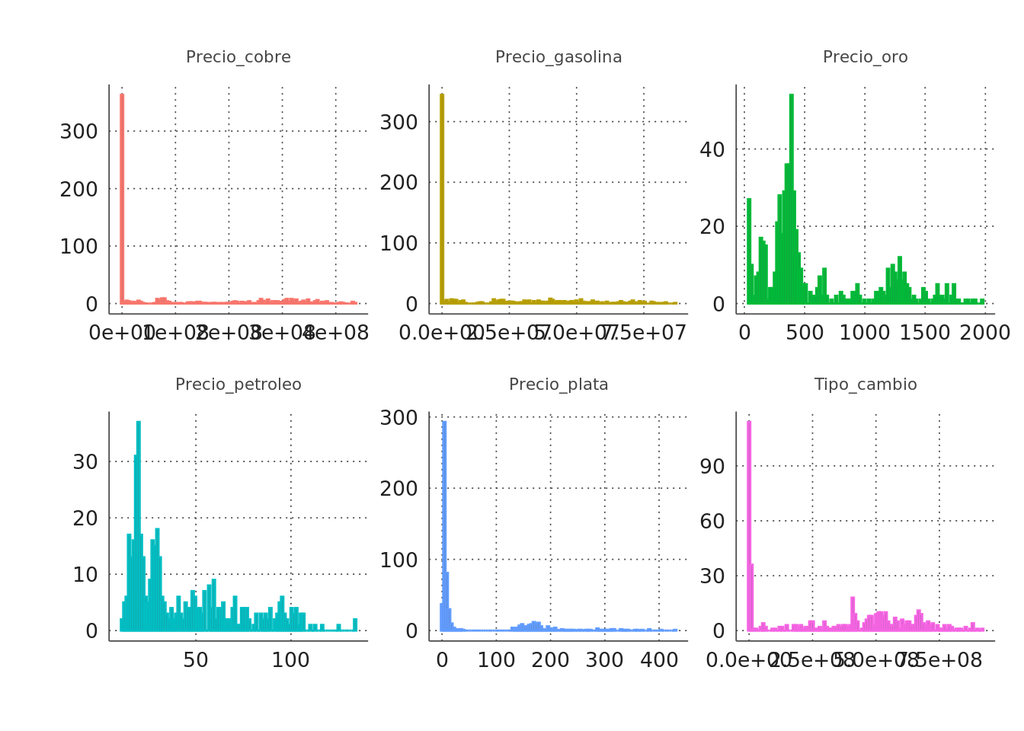

```r
top_6 <- banco %>%
    gather(key = variable, value = value, -date) %>%
    group_by(variable) %>%
    filter(!is.na(value)) %>%
    count() %>%
    arrange(desc(n)) %>%
    head(6) %>%
    pull(variable)
banco %>%
  select(date, all_of(top_6)) %>%
  rename(Precio_oro = Precio_de_la_onza_troy_de_oro_dolaresoz,
         Precio_plata = Precio_de_la_onza_troy_de_plata_dolaresoz,
         Precio_cobre = Precio_del_cobre_refinado_BML_dolareslibra,
         Precio_gasolina = Precio_de_la_gasolina_en_EEUU_dolaresm3,
         Tipo_cambio = Tipo_de_cambio_del_dolar_observado_diario,
         Precio_petroleo = Precio_del_petroleo_WTI_dolaresbarril) %>%
  gather(key = variable, value = value, -date) %>%
  ggplot(aes(x = value, color = variable)) +
    geom_histogram(bins = 100) +
    theme_fira() +
    facet_wrap(variable ~., scales = "free") +
    labs(x = "", y = "") +
    theme(legend.position = "none",
          strip.text.x = element_text(size = 8))
```

Se observa que estas variables presentan una distribución bimodal, donde en la mayoría se observa una concentración importante de observaciones con un valor cercano a 0.

### Precio de la leche

Una vez más, replicaré los pasos anteriores con los datos del precio de la leche, comenzando por visualizar los datos.

```r
leche
```

```
## # A tibble: 506 x 3
##     Anio Mes   Precio_leche
##    <int> <fct>        <dbl>
##  1  1979 Ene           3.85
##  2  1979 Feb           4.58
##  3  1979 Mar           5.18
##  4  1979 Abr           6.06
##  5  1979 May           7.25
##  6  1979 Jun           7.71
##  7  1979 Jul           8.1
##  8  1979 Ago           7.65
##  9  1979 Sep           6.96
## 10  1979 Oct           5.79
## # … with 496 more rows
```

En este caso es necesario juntar la columna Anio, mes y el día 01 para generar una columna en formato fecha, la cual se llamará date para que coincida con la de las bases de datos anteriores. Para ello sera necesario llevar la columna Mes a un número entre 1 y 12, o a los nombres de los meses en inglés para que puedan ser reconocidos.

```r
meses <- data.frame(Mes = c("Ene", "Feb", "Mar", "Abr", "May", "Jun",
                            "Jul", "Ago", "Sep", "Oct", "Nov", "Dic"),
                    N = 1:12)

leche <- leche %>%
  left_join(meses, by = "Mes") %>%
  mutate(date = paste(Anio, N, 01, sep = "-"),
         date = ymd(date)) %>%
  select(date, Precio_leche)
leche
```

```
## # A tibble: 506 x 2
##    date       Precio_leche
##    <date>            <dbl>
##  1 1979-01-01         3.85
##  2 1979-02-01         4.58
##  3 1979-03-01         5.18
##  4 1979-04-01         6.06
##  5 1979-05-01         7.25
##  6 1979-06-01         7.71
##  7 1979-07-01         8.1
##  8 1979-08-01         7.65
##  9 1979-09-01         6.96
## 10 1979-10-01         5.79
## # … with 496 more rows
```

Ahora contaré la cantidad de fechas para las que se cuenta con información del precio de la leche

```r
leche %>%
    filter(! is.na(Precio_leche)) %>%
    count()
```

```
## # A tibble: 1 x 1
##       n
##   <int>
## 1   506
```

Entonces, se cuenta con datos del precio de la leche para las 506 fechas, cuyo rango veré ahora

```r
leche %>%
  pull(date) %>%
  range()
```

```
## [1] "1979-01-01" "2021-02-01"
```

Ahora visualizaré la distribución del de esta variable por medio de un histograma.

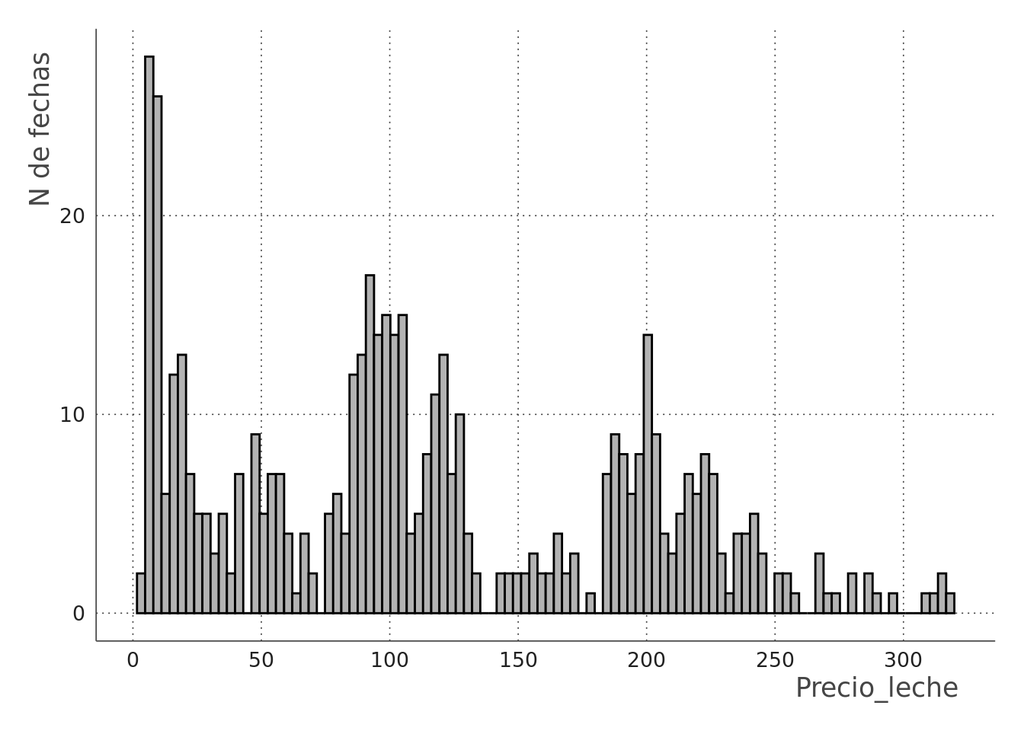

```r
leche %>%
  ggplot(aes(x = Precio_leche)) +
    geom_histogram(bins = 100, col = "black", fill = "gray70") +
    theme_fira() +
    scale_x_continuous(breaks = seq(0, 300, 50)) +
    labs(x = "Precio_leche", y = "N de fechas")
```

En este caso se observa una distribución multimodal, con modas cercanas a 0, 100 y a 200 pesos.

## Visualización

### Serie de tiempo por region

```r
plot_pp <- function(region = NULL, inicio = NULL, fin = NULL){
 regiones <- names(precip)[-1]
 fechas <- precip %>%
   pull(date) %>%
   unique() %>%
   as.character()

 if (as.Date(inicio) > as.Date(fin)){
   inicio2 <- inicio
   inicio <- fin
   fin <- inicio2
 }

 if (! region %in% regiones){
   return("La región escogida no está en el dataset")
 } else if (! inicio %in% fechas | ! fin %in% fechas){
   return("La fecha de inicio y/o final escogida no está en el dataset")
 } else{
   precip %>%
      filter(date >= inicio, date <= fin) %>%
      ggplot(aes_string(x = "date", y = region)) +
      geom_point(alpha = 0.5) +
      geom_smooth(se = F, method = "loess", span = 0.1, formula = "y ~ x") +
      theme_fira() +
      scale_x_date(breaks = "2 year",
               labels = scales::date_format("%Y")) +
      theme(axis.text.x = element_text(angle = 45, hjust = 1)) +
      labs(x = "Fecha", y = "Precipitación mensual (mm)", title = region)
 }
}

# Probando con la región mal escrita
plot_pp(region = "Ohiggins", inicio = "2000-01-01", fin = "2020-01-01")
```

```
## [1] "La región escogida no está en el dataset"
```

Probando una fecha incorrecta

```r
plot_pp(region = "OHiggins", inicio = "2000-01-10", fin = "2020-01-01")
```

```
## [1] "La fecha de inicio y/o final escogida no está en el dataset"
```

Serie de tiempo región de Ohiggins

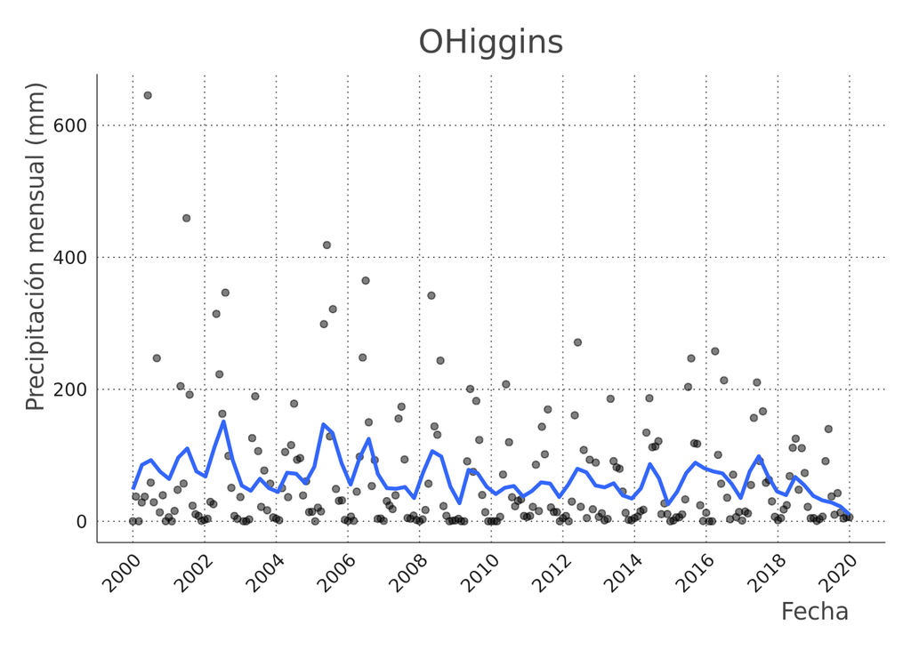

```r
plot_pp(region = "OHiggins", inicio = "2000-01-01", fin = "2020-01-01")
```

Serie de tiempo región Metropolitana

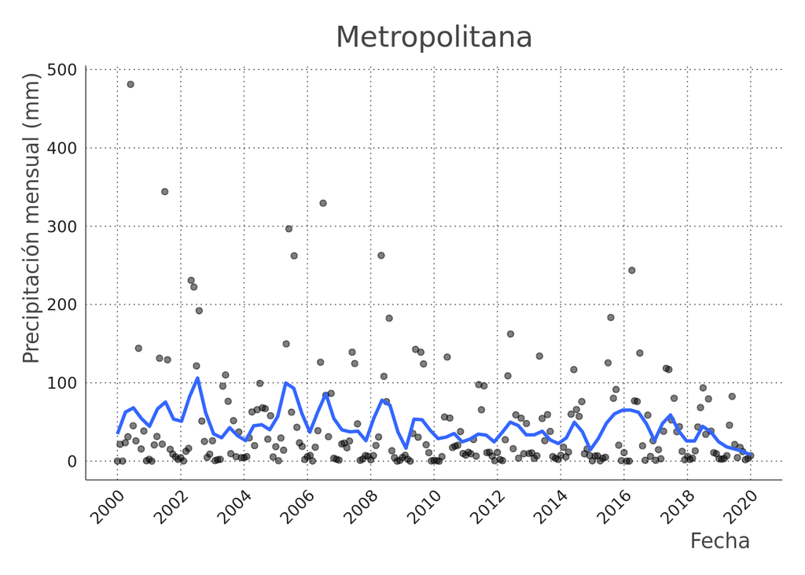

```r
plot_pp(region = "Metropolitana", inicio = "2000-01-01", fin = "2020-01-01")
```

En ambas series de tiempo se observa en primer lugar, que en la región de OHiggins se alcanzan precipitaciones ligeramente superiores a las de la región metropolitana. Por otra parte, en ambas figuras se observa una estacionalidad donde las precipitaciones se concentran en los meses de invierno. Finalmente, es posible visualizar una disminución en las precipitaciones alcanzadas durante los meses de invierno con el transcurso de los años.

### Serie de tiempo para años seleccionados

```r
plot_pp_anios <- function(region = NULL, anios = NULL){
 regiones <- names(precip)[-1]
 anios_todos <- precip %>%
   pull(date) %>%
   year() %>%
   unique() %>%
   as.character()

 anios <- anios %>% as.character()

 if (! region %in% regiones){
   return("La región escogida no está en el dataset")
 } else if (sum(! anios %in% anios_todos) > 0){
   return("No se cuenta con datos para al menos uno de los años escogidos")
 } else{
   precip %>%
      mutate(year = year(date),
             mes = month(date)) %>%
      filter(year %in% anios) %>%
      mutate(date2 = ymd(paste(2000, mes, "01", sep = "-"))) %>% #Genero una fecha falsa para el gráfico, en la que todas las fechas se encuentran dentro del año 2000 (bisiesto)
      ggplot(aes_string(x = "date2", y = region)) +
      geom_point(alpha = 0.5) +
      geom_line() +
      facet_grid(year ~.) +
      theme_fira() +
      scale_x_date(breaks = "1 month",
               labels = scales::date_format("%b")) +
      labs(x = "Fecha", y = "Precipitación mensual (mm)")
 }
}

# Probando con año no inlcuido
plot_pp_anios(region = "OHiggins", anios = c(2010,2011,2022))
```

```
## [1] "No se cuenta con datos para al menos uno de los años escogidos"
```

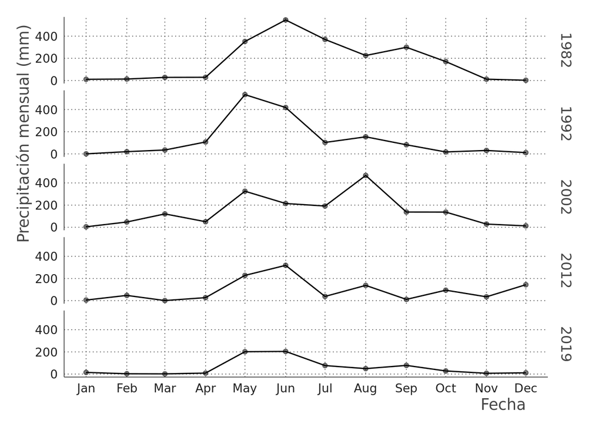

```r
plot_pp_anios(region = "Maule", anios = c(1982, 1992, 2002, 2012, 2019))
```

Al observar estas series de tiempo se observa que las mayores precipitaciones se concentran entre los meses de mayo y agosto. Por otra parte, se observa una disminución en las precipitaciones alcanzadas en la región del Maule, ya que hasta el año 2002 se alcanzaron meses con precipitaciones acumuladas sobre 400 mm, mientras que durante el año 2012 solo se llegó a una precipitación cercana a los 300 mm durante junio, y ya durante el 2019 los meses con mayores precipitaciones solo se acercaron a los 200 mm.

### Series temporales PIB

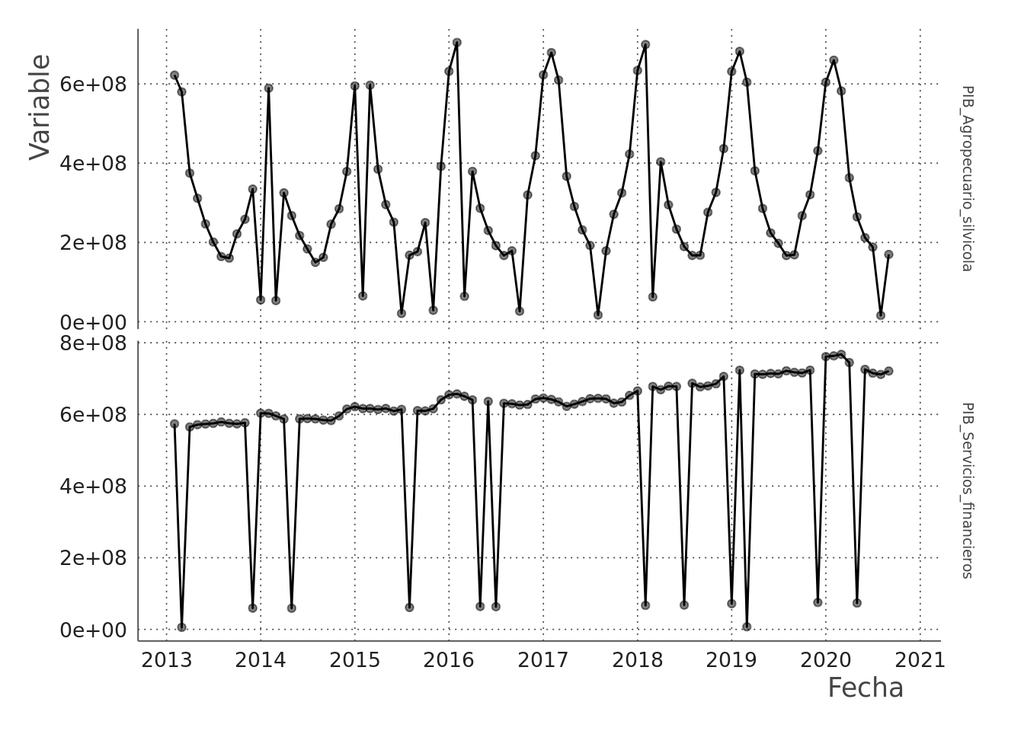

```r
# La función tendrá por defecto a la fecha actual como fecha de término.

plot_pp <- function(series = NULL, inicio = NULL, fin =  Sys.Date()){
banco %>%
    select(date, all_of(series)) %>%
    filter(date >= inicio, date <= fin) %>%
    gather(variable, value, -date) %>%
    ggplot(aes(x = date, y = value)) +
      geom_point(alpha = 0.5) +
      geom_line() +
      facet_grid(variable ~., scale = "free_y") +
      theme_fira() +
      theme(strip.text.y.right = element_text(size = 7)) +
      labs(x = "Fecha", y = "Variable")  +
      scale_x_datetime(breaks = "1 year",
               labels = scales::date_format("%Y"))
}

# Pruebo la función
series <- c("PIB_Agropecuario_silvicola", "PIB_Servicios_financieros")
inicio <- "2013-01-01"
plot_pp(series = series, inicio = "2013-01-01")
```

Al observar la serie temporal del PIB Agropecuario Silvícola se observa que esta presenta un comportamiento estacional con máximos durante los veranos. Por otra parte, el PIB de servicios financieros presenta una estacionalidad menos marcada, donde también se alcanzan los máximos en verano, y además muestra una tendencia ascendente constante desde el 2013 en adelante. Ambas series de tiempo presentan valores que podrían ser erróneos, ya que se observan disminuciones puntuales abruptas, sin embargo, desconozco si estas variaciones son naturales en este tipo de variables y en honor al tiempo, voy a considerar que son válidas. Por otra parte, dado que ambas series temporales tienden a aumentar durante la época estival, estas deben presentar una relación directa, lo cuál debiese estudiarse mediante un test de correlación, lo cual se abordará en la siguiente sección.

## Tratamiento y creación de variables

La correlación se puede evaluar aplicando algún test como el de pearson o spearman donde se obtiene un valor entre -1 y 1, en donde los valores positivos representan una correlación directa, y los valores negativos señalan una correlación inversa. En ambos casos, mientras el valor sera más lejano de 0 indicará una correlación más fuerte, sin embargo, esta es una medida de la relación lineal que existe entre dos variables, y por lo tanto métodos de machine learning, que consideran otros tipos de relaciones, pueden llegar a ajustes altos en base a variables que tienen una correlación no necesariamente tan alta con la variable a predecir, y a las interacciones que se dan entre ellas.

A la hora de entrenar un modelo, el primer paso es definir cuál será la variable a predecir, que en este caso es el precio de la leche. Luego, se deben recopilar distintas variables predictoras que tienen o podrían tener una relación con la variable a predecir. Actualmente, usualmente hay acceso a una variedad importante de variables que podrían utilizarse, en cuyos casos se debe aplicar un proceso de selección de variables o feature selection, los cuales nos permiten identificar aquellas variables que más aportan a mejorar la precisión del modelo. Al mismo tiempo, es importante tener un conocimiento de base o background de lo que se está modelando, de manera de tener al menos una noción de que el rango de valores con los que se cuentan son los suficientes para hacer un modelo robusto ante aplicaciones en sets de datos diferentes.

Ahora realizaré el merge de los datos y la creación de nuevas variables que podrían ayudar a la predicción del precio de la leche, tales como valores medios del PIB, Imacec y precipitaciones, y los lags o diferencia de los valores con respecto al valor anterior. En el caso de los datos del banco central, solo consideraré las variables que cuenten con 200 datos válidos o más, con el fin de quedarme con una buena cantidad de filas u observaciones para darle más robustez a la modelación.

Adicionalmente se hará un test de correlación con algunas variables a modo de ejemplo. Para ello realicé una búsqueda rápida en Google donde encontré un [artículo](https://blog.especialistasennovillas.es/posts/el-precio-de-la-leche.aspx) que menciona un dato que desconocía que se refiere a la relación existente entre el precio del petroleo y el precio de la leche, por lo tanto ahora veré si esta correlación se cumple en nuestro set de datos.

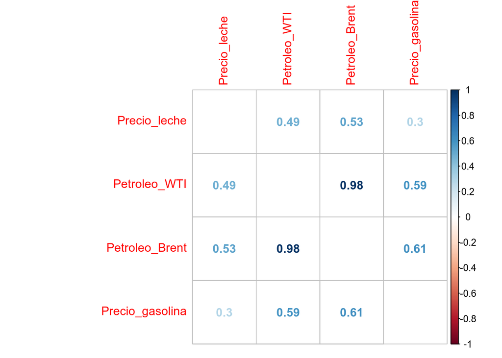

```r
seleccion_banco <- contarbanco %>%
  filter(n > 200) %>%
  pull(variable)

bdfinal <- leche %>%
  left_join(banco %>%
                mutate(Media_PIB = rowMeans(select(., starts_with("PIB")), na.rm = TRUE),  #Agrego PIB medio
                       Media_Imacec = rowMeans(select(., starts_with("Imacec")), na.rm = TRUE),
                       Media_PIB_lag = Media_PIB - lag(Media_PIB, default = 0), #Calculo diferencia del PIB medio con respecto a la medición anterior
                       Media_Imacec_lag = Media_Imacec - lag(Media_Imacec, default = 0), #Calculo diferencia del IMACEC medio con respecto a la medición anterior
                       PIB_lag = PIB - lag(PIB, default = 0),#Calculo diferencia del PIB con respecto a la medición anterior
                       PetroleoWTI_lag = Precio_del_petroleo_WTI_dolaresbarril - lag(Precio_del_petroleo_WTI_dolaresbarril, default = 0), #Lag petroleo WTI
                       PetroleoBrent_lag = Precio_del_petroleo_Brent_dolaresbarril - lag(Precio_del_petroleo_Brent_dolaresbarril, default = 0)) %>% #Lag petroleo Brent
              select(date, all_of(seleccion_banco)),
                by = "date") %>%
  left_join(precip %>%
                mutate(Media_PP = rowMeans(select(., -date), na.rm = TRUE), #Agrego precipitación media
                       Media_PP_lag = Media_PP - lag(Media_PP, default = 0)), #Calculo diferencia de la precipitación con medición anterior
                by = "date") %>%
  mutate(anio = year(date), #creo columna con el año
         month = month(date), #creo columna con el mes
         week = week(date), #creo columna con la semana
         semestre = semester(date), #creo columna con el semestre
         trimestre = quarter(date)) %>%  #creo columna con el trimestre
  na.omit()

bdfinal %>%
  select(Precio_leche, Petroleo_WTI = Precio_del_petroleo_WTI_dolaresbarril, Petroleo_Brent = Precio_del_petroleo_Brent_dolaresbarril, Precio_gasolina = Precio_de_la_gasolina_en_EEUU_dolaresm3) %>%
  cor(use = "pairwise.complete.obs") %>%
  corrplot(method = 'number', diag = FALSE)
```

En la figura se observa que en este set de datos también existe una correlación importante entre el precio de la leche y el precio del petroleo, sobre todo en su medición Brent (r = 0.53). Por otra parte, su relación con el precio de la gasolina es bastante más sutil (r = 0.3).

## Modelo

De forma previa al modelo realizaré algunos pasos de preprocesamiento: En primer lugar voy a identificar si existen variables con poca variabilidad dentro del set de datos con el fin de no considerarlas, estoy lo voy a realizar por medio de la función nearZeroVar de la librería caret.

```r
nzv <- nearZeroVar(bdfinal)
nzv
```

```
## integer(0)
```

De acuerdo a este análisis, no existe ninguna variable con poca o nula variabilidad y por lo tanto, no eliminaré ninguna de nuestro set de datos.

Por otra parte, realizaré una estandarización de los predictores, dado que no estoy seguro de los datos del banco central esten en las unidades correctas ya que eliminé los puntos que se habían leído en un comienzo, y de esta manera todas las variables tendrán una media 0 y desviación estándar 1, con la excepción de la fecha y el precio de la leche

```r
bdfinal <- bdfinal %>%
  select(date, Precio_leche) %>%
  cbind(bdfinal %>%
          select(-date, -Precio_leche) %>%
          mutate_all(scale))
```

Ahora realizaré un proceso de feature selection llamado Boruta, ya que se basa en un algoritmo de Random Forest, el cual utilizaremos para finalmente modelar el precio de la leche. Este proceso separa todas las columnas de la base de datos en 3 categorías: Importantes, posibles o tentativos y sin importancia. En el caso de este ejercicio me quedaré solo con las variables importantes.

```r
boruta_output <- Boruta(Precio_leche ~ ., data=bdfinal, doTrace=0, maxRuns = 50)
boruta_signif <- getSelectedAttributes(boruta_output, withTentative = FALSE)
boruta_signif
```

```
##  [1] "date"
##  [2] "Precio_de_la_onza_troy_de_oro_dolaresoz"
##  [3] "Precio_de_la_onza_troy_de_plata_dolaresoz"
##  [4] "Precio_del_cobre_refinado_BML_dolareslibra"
##  [5] "Precio_de_la_gasolina_en_EEUU_dolaresm3"
##  [6] "Tipo_de_cambio_del_dolar_observado_diario"
##  [7] "Precio_del_petroleo_WTI_dolaresbarril"
##  [8] "Indice_de_produccion_industrial__mineria"
##  [9] "Indice_de_produccion_industrial__manufacturera"
## [10] "Imacec_a_costo_de_factores"
## [11] "Imacec_comercio"
## [12] "Imacec_empalmado"
## [13] "Imacec_industria"
## [14] "Imacec_no_minero"
## [15] "Imacec_produccion_de_bienes"
## [16] "Imacec_resto_de_bienes"
## [17] "Imacec_servicios"
## [18] "Generacion_de_energia_electrica_CDEC_GWh"
## [19] "Precio_del_gas_natural_dolaresmillon_de_unidades_termicas_britanicas"
## [20] "Precio_del_kerosene_dolaresm3"
## [21] "Precio_del_petroleo_Brent_dolaresbarril"
## [22] "Los_Rios"
## [23] "anio"
```

Ahora separaré la base de datos entre entrenamiento y validación. Para ello realizaré una separación aleatórea de un 70% para entrenamiento y 30% para validación, dado que finalmente se cuenta con 244 observaciones. El porcentaje suelo decidirlo en base a la cantidad de datos con los que dispongo, donde sobre las 1000 observaciones ya utilizo un 80% para entrenamiento.

```r
bdfinal <- bdfinal %>%
  select(Precio_leche, all_of(boruta_signif))

set.seed(1234) #creo semilla para que sea reproducible
trainIndex <- createDataPartition(bdfinal$Precio_leche, p = .7,
                                  list = FALSE,
                                  times = 1)
train <- bdfinal[ trainIndex,]
test  <- bdfinal[-trainIndex,]

rf <- randomForest(Precio_leche ~ ., data = train)

test <- test %>%
  select(date, Precio_leche) %>%
  mutate(Prediccion = predict(rf, test))
```

En primer lugar realizaremos un análisis visual de la calidad de la prediccción al comparar la serie de tiempo del precio de la leche real versus el resultado del modelo

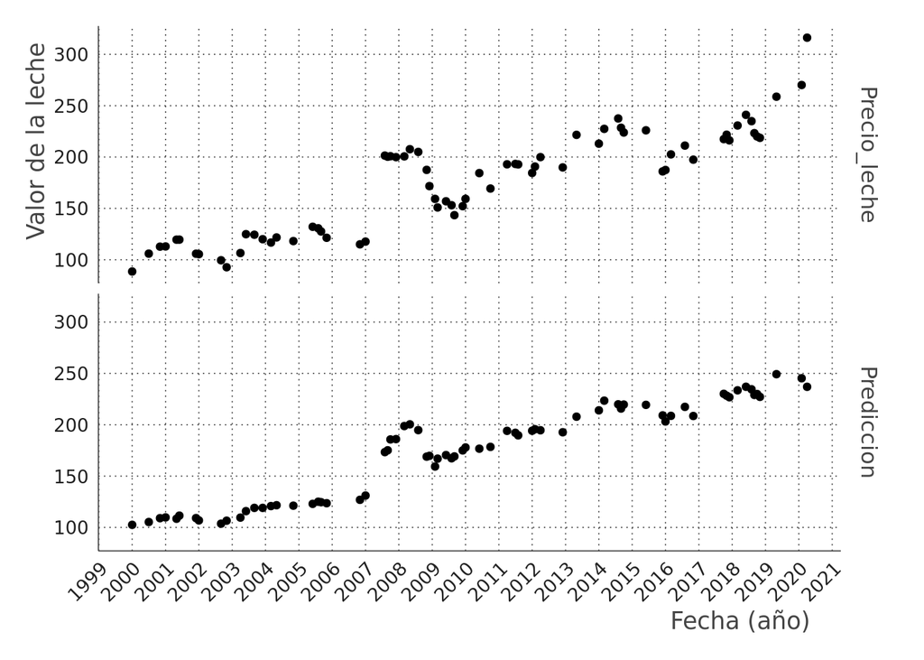

```r
test %>%
  gather(variable, value, -date) %>%
  ggplot(aes(x = date, y = value)) +
    geom_point() +
    theme_fira() +
    facet_grid(variable~.) +
    scale_x_datetime(breaks = "1 year",
               labels = scales::date_format("%Y")) +
    labs(x = "Fecha (año)", y = "Valor de la leche") +
    theme(axis.text.x = element_text(angle = 45, hjust = 1))
```

En este se observa que el precio de la leche muestra una tendencia ascendente, la cual es reproducida correctamente por el modelo. De forma complementaria, es necesario calcular algunos parámetros claves de la modelación: el coeficiente de determinación (r cuadrado) y el error cuadrático medio (RMSE)

```r
rsq <- function (x, y) cor(x, y) ^ 2
data.frame(Parámetro = c("R2", "RMSE"),
           valor = c(rsq(test$Precio_leche, test$Prediccion),
                     ModelMetrics::rmse(test$Precio_leche, test$Prediccion)))
```

```
##   Parámetro      valor
## 1        R2  0.9154232
## 2      RMSE 14.5893121
```

En cuanto a la evaluación de los resultados, me parece que para ser un ejercicio los ajustes alcanzados son bastante buenos, considerando especialmente un error cuadrático medio de 14.6 pesos y que por tanto es un buen caso a seguir desarrollando de manera de entender cuál es la relación con los distintos predictores, probar otros algoritmos de selección de variables y de modelación.

De haber tenido un poco más de tiempo, me hubiese gustado incorporar como variable predictora a la temperatura del aire de la zona productora, en especial las temperaturas extremas dado que pueden afectar tanto al crecimiento de los pastizales como al desarrollo y condición de las vacas. Asi mismo, me gustaría investigar sobre otros factores que podrían influir y evaluar la posibilidad de incluirlos

Finalmente, encontré muy interesante asociar el valor de un alimento básico a variables económicas y ambientales. Ante los distintos escenarios de cambio climático que se proyectan se podría generar una predicción del precio de la leche que considere las proyecciones de precipitaciones, temperaturas y precio de los combustibles fósiles.